# Trifold™ logo concepts

Four concepts for the Trifold mark, each in three colour themes, at 512, 64, 32 and 16 px, with favicons, the horizontal lockup and animations. The owner asked for a triangular, sacred-geometry mark that folds in three dimensions and in a cycle, so the two triangle concepts lead: A, turned corners (Grok's round-2 concept, put on a construction), and B, the turning fold. C and D are the two strongest receipt concepts from round 1, redrawn after Grok's critique. Every SVG on this page is inlined, so the page works on its own.

Concepts only. The final mark waits for the trademark clearance search (TRADEMARKS.md; the business plan's risks). Use ™, never ®. Copyright 2026 Trifold. All rights reserved.

**Recommendation.** Concept A, turned corners, in the Paper theme (an ink sheet with three saffron folded corners, on cream), with the fold-once animation on page load and the cyclical fold as the hero animation. Night is the dark-mode pair. If the trademark search finds hexagon or triangle marks crowded in classes 9, 36 and 42, fall back to concept D.

Your system asks for reduced motion, so the animations below show the static mark.

## Concept A: Turned corners (lead)

One sheet, three corners folded in. An equilateral triangle has each corner folded on a crease parallel to the opposite side, a quarter of the side deep, so every folded tip lands on the circle a quarter the size of the circumcircle: three folds, equal and 120 degrees apart, that agree without touching. The ink is the front of the paper and the saffron is its back, so the mark reads as folded paper, not as a solid or a pyramid. Every corner can fold out to complete the triangle and fold back in without leaving it, which makes the cyclical animation honest. Grok proposed the turned corners in round 2; the construction, themes and motion are ours.

#### Concept A · Paper: ink on cream, saffron accent

[figure not shown]

512

64

32

16

fav 32

fav 16

#### Concept A · Ledger: green and ink on cream

[figure not shown]

512

64

32

16

fav 32

fav 16

#### Concept A · Night: cream and saffron on ink

[figure not shown]

512

64

32

16

fav 32

fav 16

### Animated

[figure not shown]

A · cyclical fold, 7.2 s loop · Paper

[figure not shown]

A · cyclical fold, 7.2 s loop · Night

[figure not shown]

A · folds once on load, then rests · Paper

[figure not shown]

A · folds once on load, then rests · Night

[figure not shown]

A · cyclical fold + glint and glass sheen · Paper

[figure not shown]

A · cyclical fold + glint and glass sheen · Night

### Construction, one colour, motion frames

[figure not shown]

Construction: circumcircle (R), R/2 and R/4 circles, a compass of a quarter side at each corner, the three creases, the tips on the R/4 circle

[figure not shown]

One colour (folds drawn by cuts in the page colour)

One colour, 16 px

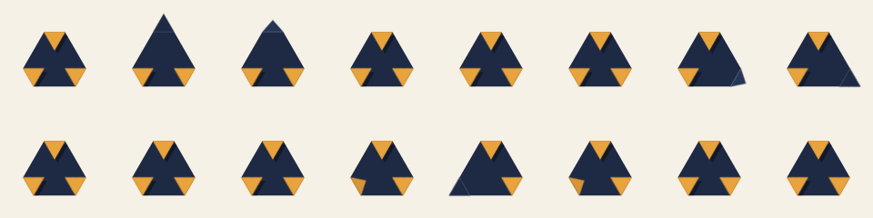

The cyclical fold, 16 frames over one 7.2 s loop (left to right, top to bottom)

## Concept B: Turning fold

The first triangle answer. Three lines through the centre, each parallel to a side, cut every side in thirds and split the triangle into nine small triangles and three equal trapezoid flaps that turn one way (order-3 rotational symmetry, no mirror). Light, mid and dark facets and a thin tuck shadow make it read in three dimensions. Grok scored it 5/10: the seams radiate from an interior point, so strangers read a pyramid or a low-poly peak, and a flap folded about a radius cannot land inside the triangle. Kept as the alternate triangle; the motion has Grok's fixes (a 0.15 edge-on floor, a colour crossfade, an ink footprint instead of a second paper colour, half the loop at rest).

#### Concept B · Paper: ink on cream, saffron accent

[figure not shown]

512

64

32

16

fav 32

fav 16

#### Concept B · Ledger: green and ink on cream

[figure not shown]

512

64

32

16

fav 32

fav 16

#### Concept B · Night: cream and saffron on ink

[figure not shown]

512

64

32

16

fav 32

fav 16

### Animated

[figure not shown]

B · cyclical turn · Paper

[figure not shown]

B · cyclical turn · Night

### Construction, one colour, motion frames

[figure not shown]

Construction: circumcircle and incircle, a compass of a third side at each corner, the thirds grid, the three cuts

[figure not shown]

One colour

## Concept C: Z-fold receipt

A receipt folded like an accordion in thirds and seen in perspective: three panels, the middle one turned the other way. The most literal receipt folded in three. Redrawn twice after Grok: no gaps (the colour change is the crease), a stronger slant, one flat baseline with a chamfer on each outer corner instead of torn teeth, because the slant is the fold.

#### Concept C · Paper: ink on cream, saffron accent

[figure not shown]

512

64

32

16

fav 32

fav 16

#### Concept C · Ledger: green and ink on cream

[figure not shown]

512

64

32

16

fav 32

fav 16

#### Concept C · Night: cream and saffron on ink

[figure not shown]

512

64

32

16

fav 32

fav 16

### Animated

[figure not shown]

C · glimmer, light across the folds · Paper

[figure not shown]

C · glimmer · Night

## Concept D: Three columns, one check

The receipt opened flat into its three columns (books, receipt, Stripe) with one check running across all three: the records agree, and anyone can check. The clearest at 16 px. Redrawn after Grok: 4-unit gaps that survive at 16 px, a lighter check, and a halo that is always the page colour. Grok would delete the check (it calls the mark a verified badge); we kept it because the check across all three columns is the idea.

#### Concept D · Paper: ink on cream, saffron accent

[figure not shown]

512

64

32

16

fav 32

fav 16

#### Concept D · Ledger: green and ink on cream

[figure not shown]

512

64

32

16

fav 32

fav 16

#### Concept D · Night: cream and saffron on ink

[figure not shown]

512

64

32

16

fav 32

fav 16

### Animated

[figure not shown]

D · unfolds into three, then the check · Paper

[figure not shown]

D · unfolds into three, then the check · Night

## Round 1 explorations

Round 1 had four receipt concepts. Grok scored them A 6, B 5, C 3, D 4 out of 10. The folded T and the fold-check strip were dropped; the Z-fold and the three columns were redrawn as today's C and D.

A · Z-fold receipt  
Redrawn as concept C

B · Three columns, one check  
Redrawn as concept D

C · Folded T  
Dropped: a crowded monogram, read as a hammer

D · Fold-check strip  
Dropped: a generic ribbon check